# Daily Mean Radiation Products from Ground-based observations and Satellite data

Marieke Dirksen

September, 2016

# Loading Packages

The data from the hdf5 files is loaded with the R package rhdf5. From the .h5 files a raster is created, filped and croped using the R’s package raster. The data from the ground based observations is read with the data.table function fread. For the geostatistical analysis we need the automap package. The machine learning algorithms from the caret package are used.

```r
library(adehabitat)
library(automap)
library(caret)
# library(caretEnsemble)
library(data.table)
# library(doParallel)
# library(foreach)
library(GSIF)
library(kernlab)
library(maptools)
library(reshape)
library(raster)
library(rgdal)
library(rhdf5)
library(SDMTools)
data(wrld_simpl)
```

# Color settings for plotting routine

For all the plotting routines we use the same color settings.

```r
kleur.breaks<-seq(0,500,by=10)
kleur.cols<-terrain.colors(length(kleur.breaks-1))
```

# Functions

Defining some basic functions.

```r
rmse<-function(sim,obs){
  rmse=sqrt(mean((sim-obs)^2,na.rm=TRUE))
}

r2<-function(residual,observed){
  teller <- sum(residual^2)
  noemer <- sum((observed-mean(observed))^2)
  r2 <- 1 - teller/noemer
  return(r2)
}
```

## Surface irradiance

Loading the attributes “direct irradiance” and “diffuse irradiance” to calculate the total irradiance. Also the satellite grid coordinates “lat” and “lon” are loaded.

```r
time<-as.POSIXct("2014-07-04")
file<-"/net/pc150398/nobackup_1/users/meirink/siccs_wouter/SICCS/daymean/harmonie_proj/daymean_reproj_20140704.h5"
h5ls(file)
```

```
##   group                   name       otype dclass    dim
## 0     /         TOA irradiance H5I_DATASET  FLOAT  x 300
## 1     /     diffuse irradiance H5I_DATASET  FLOAT  x 300
## 2     / diffuse transmissivity H5I_DATASET  FLOAT  x 300
## 3     /      direct irradiance H5I_DATASET  FLOAT  x 300
## 4     /  direct transmissivity H5I_DATASET  FLOAT  x 300
## 5     /                    lat H5I_DATASET  FLOAT    300
## 6     /                    lon H5I_DATASET  FLOAT    300
## 7     /                quality H5I_DATASET  FLOAT  x 300
```

```r
data.direct.irradiance<-h5read(file,"direct irradiance")
data.diffuse.irradiance<-h5read(file,"diffuse irradiance")
data.total.irradiance<-data.direct.irradiance+data.diffuse.irradiance
data.total.irradiance<-t(data.total.irradiance)

data.lat<-h5read(file,"/lat") #Latitude
data.lon<-h5read(file,"/lon") #Longitude
```

## Satellite grid

Now we have all the satellite data we create a raster object.

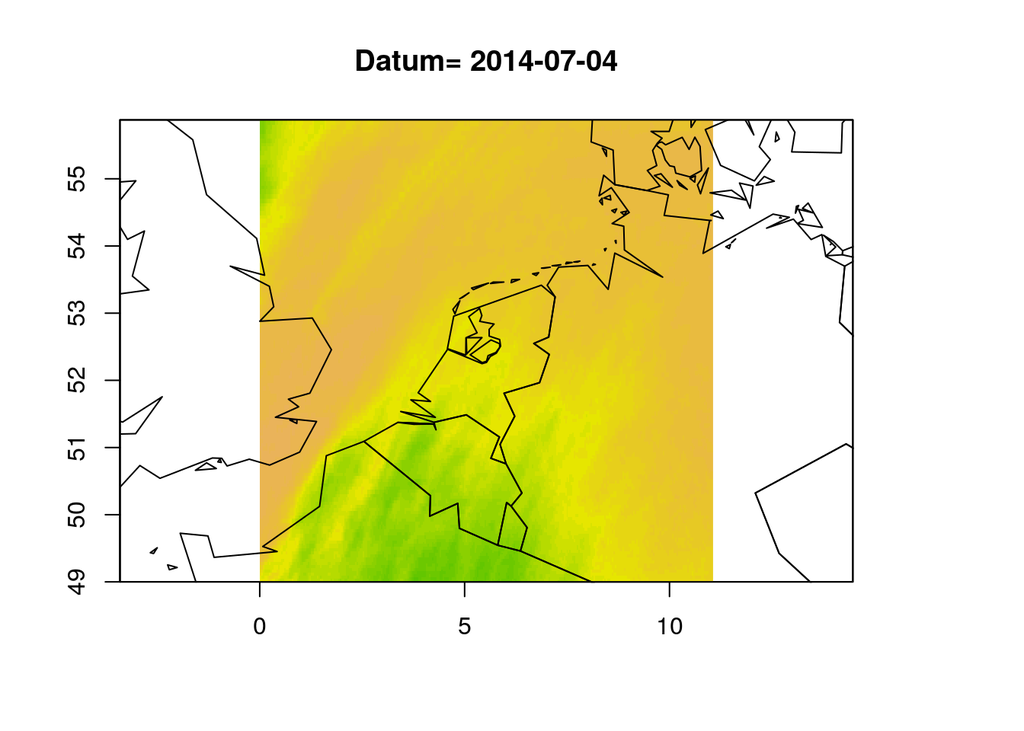

```r
data.lat[which(data.lat==-999)]<-NA # replace no data value with NA (this case -999)
data.lon[which(data.lon==-999)]<-NA # replace no data value with NA (this case -999)

r<-raster(data.total.irradiance,crs=CRS("+init=epsg:4326"),
      xmn=min(data.lon,na.rm=T),
      xmx=max(data.lon,na.rm=T),
      ymn=min(data.lat,na.rm=T),
      ymx=max(data.lat,na.rm=T))
rr<-flip(r,direction='y')
plot(rr,main=paste("Datum=",time),col=kleur.cols,breaks=kleur.breaks,legend=F)
plot(wrld_simpl,add=TRUE)
```

# Reprojecting raster and cropping

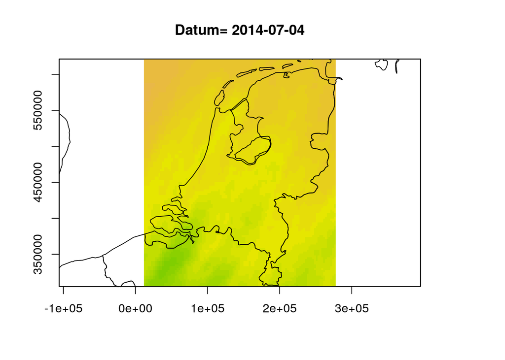

```r
pro=CRS("+init=epsg:28992")
#Natural Earth dataset: unprojected shape files
mymap.unpro=readOGR(dsn='Rdata/NaturalEarthData/ne_10m_admin_0_countries',layer="ne_10m_admin_0_countries") # Read in (unprojected) map data
mymap.pro=spTransform(mymap.unpro, pro) # Reproject the map

mymap.unpro_lakes=readOGR(dsn='Rdata/NaturalEarthData/ne_10m_lakes',layer="ne_10m_lakes") # Read in (unprojected) map data
mymap.pro_lakes=spTransform(mymap.unpro_lakes, pro) # Reproject the map

rr<-projectRaster(rr,crs=pro)
r.NED<-crop(rr,extent(12621.630033977,278621.630033977,305583.0457758,620583.0457758))

plot(r.NED,col=kleur.cols,breaks=kleur.breaks,main=paste("Datum=",time),legend=F)
plot(mymap.pro,add=TRUE)
plot(mymap.pro_lakes,add=TRUE)
```

# Data from observations

From the observations a subset is made (2014/07/04), coordinates are stored in a seperate file and merged with the dataset.

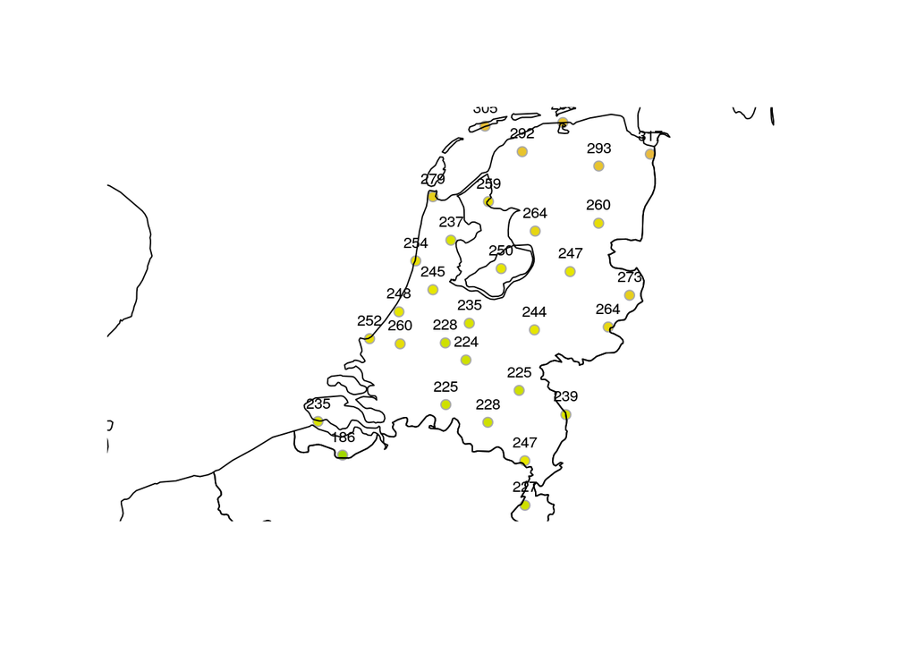

```r
# coords<-fread("Rdata/radiation_KNMI_day.csv")
# coords<-subset(coords,select=c("DS_LAT","DS_LON","DS_CODE"))
# coords<-unique(coords)
#saveRDS(coords,file="Rdata/coordsKNMI.rda")
coords<-readRDS("Rdata/coordsKNMI.rda")

obs<-fread("Rdata/radiation_KNMI_day_v2.csv")
obs$IT_DATETIME<-as.POSIXct(obs$IT_DATETIME,format="%Y%m%d_240000_000000")

obs.subset<-obs[which(IT_DATETIME==time),]
obs.subset$Q<-obs.subset$REH1.Q24*10000/(24*3600)
obs.subset<-merge(obs.subset,coords,by="DS_CODE")
obs.subset<-na.omit(obs.subset,cols=c("DS_LAT","DS_LON","Q"))

coordinates(obs.subset)<-~DS_LON+DS_LAT
proj4string(obs.subset)<-CRS("+init=epsg:4326")
obs.subset<-spTransform(obs.subset,pro)

kleur.data<-cut(obs.subset$Q,breaks=kleur.breaks,include.lowest=TRUE,labels=FALSE)
plot(obs.subset,bg=(kleur.cols[kleur.data]),
     col="darkgrey",pch=21)
text(obs.subset$DS_LON,obs.subset$DS_LAT,round(obs.subset$Q,0),pos=3,cex=0.7)
plot(mymap.pro,add=TRUE)
plot(mymap.pro_lakes,add=TRUE)
```

## Test and Train set

For the splitting of the train and test set we want all the data from 1 day, as we only have 33 observations. A post on splitting with timeslices can be found [here](http://stackoverflow.com/questions/24758218/time-series-data-spliting-and-model-evaluation). Also on Github some more background information can be [found](http://topepo.github.io/caret/data-splitting.html).

> Note that these methods can also be included in the trainControl function (see stackoverflow link). The trainControl would look something like: trainControl(method=‘cv’, index=createFolds(obs,list = TRUE)). Here we explore how the functions work for subsetting the data. If we want to make a train and subset for each day we probably need to do this by hand. Another important discussion on cross-validation and data splitting can be found [here](http://stats.stackexchange.com/questions/188955/is-it-necessary-to-split-dataset-for-cross-validation).

```r
obs<-obs[complete.cases(obs$REH1.Q24),]
timestamps<-unique(obs$IT_DATETIME)

#Create Folds
time.folds<-createFolds(timestamps,3)

time.trainFolds<-time.folds[[1]]
time.testFolds<-time.folds[[2]]
time.validateFolds<-time.folds[[3]]

time.trainSet<-timestamps[time.trainFolds]
time.testSet<-timestamps[time.testFolds]
time.validateSet<-timestamps[time.validateFolds]

print(head(time.trainSet))
```

```
## [1] "2004-01-21 GMT" "2004-01-24 GMT" "2004-01-29 GMT" "2004-01-30 GMT"
## [5] "2004-02-03 GMT" "2004-02-05 GMT"
```

```r
print(head(time.testSet))
```

```
## [1] "2004-01-23 GMT" "2004-01-25 GMT" "2004-01-27 GMT" "2004-01-28 GMT"
## [5] "2004-01-31 GMT" "2004-02-01 GMT"
```

```r
print(head(time.validateSet))
```

```
## [1] "2004-01-17 GMT" "2004-01-18 GMT" "2004-01-19 GMT" "2004-01-20 GMT"
## [5] "2004-01-22 GMT" "2004-01-26 GMT"
```

```r
#Time slices
I.Sub.TimeSlices<-createTimeSlices(y=as.vector(timestamps),initialWindow = 32,horizon=32,fixedWindow = FALSE)

str(I.Sub.TimeSlices,max.level=1)
```

```
## List of 2
##  $ train:List of 4515
##   .. [list output truncated]
##  $ test :List of 4515
##   .. [list output truncated]
```

```r
time.trainSlices<-I.Sub.TimeSlices[[1]]
time.testSlices<-I.Sub.TimeSlices[[2]]

time.trainSet<-timestamps[time.trainSlices[[1]]]
time.testSet<-timestamps[time.testSlices[[1]]]

print(time.trainSet)
```

```
##  [1] "2004-01-17 GMT" "2004-01-18 GMT" "2004-01-19 GMT" "2004-01-20 GMT"
##  [5] "2004-01-21 GMT" "2004-01-22 GMT" "2004-01-23 GMT" "2004-01-24 GMT"
##  [9] "2004-01-25 GMT" "2004-01-26 GMT" "2004-01-27 GMT" "2004-01-28 GMT"
## [13] "2004-01-29 GMT" "2004-01-30 GMT" "2004-01-31 GMT" "2004-02-01 GMT"
## [17] "2004-02-02 GMT" "2004-02-03 GMT" "2004-02-04 GMT" "2004-02-05 GMT"
## [21] "2004-02-06 GMT" "2004-02-07 GMT" "2004-02-08 GMT" "2004-02-09 GMT"
## [25] "2004-02-10 GMT" "2004-02-11 GMT" "2004-02-12 GMT" "2004-02-13 GMT"
## [29] "2004-02-14 GMT" "2004-02-15 GMT" "2004-02-16 GMT" "2004-02-17 GMT"
```

```r
print(time.testSet)
```

```
##  [1] "2004-02-18 GMT" "2004-02-19 GMT" "2004-02-20 GMT" "2004-02-21 GMT"
##  [5] "2004-02-22 GMT" "2004-02-23 GMT" "2004-02-24 GMT" "2004-02-25 GMT"
##  [9] "2004-02-26 GMT" "2004-02-27 GMT" "2004-02-28 GMT" "2004-02-29 GMT"
## [13] "2004-03-01 GMT" "2004-03-02 GMT" "2004-03-03 GMT" "2004-03-04 GMT"
## [17] "2004-03-05 GMT" "2004-03-06 GMT" "2004-03-07 GMT" "2004-03-08 GMT"
## [21] "2004-03-09 GMT" "2004-03-10 GMT" "2004-03-11 GMT" "2004-03-12 GMT"
## [25] "2004-03-13 GMT" "2004-03-14 GMT" "2004-03-15 GMT" "2004-03-16 GMT"
## [29] "2004-03-17 GMT" "2004-03-18 GMT" "2004-03-19 GMT" "2004-03-20 GMT"
```

```r
#create Data Partition
I.Sub<-createDataPartition(obs$REH1.Q24,p=0.05,list=FALSE)
```

# Compare the two products

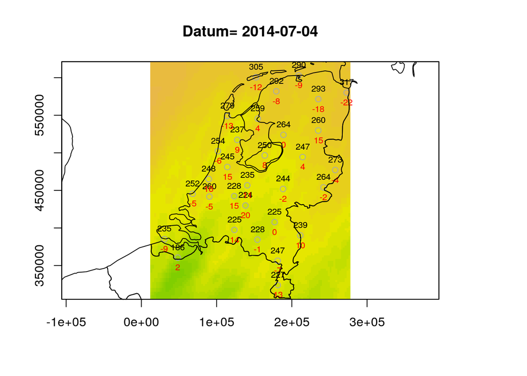

```r
rASC<-asc.from.raster(r.NED)
spdf<-asc2spixdf(rASC)
proj4string(spdf)<-pro

var.Q<-subset(obs.subset,select=Q)
sat.var<-over(var.Q,spdf)

n<-names(sat.var)
diff<-sat.var[n]-var.Q$Q

plot(r.NED,col=kleur.cols,breaks=kleur.breaks,main=paste("Datum=",time),legend=F)
plot(obs.subset,bg=(kleur.cols[kleur.data]),
     col="darkgrey",pch=21,add=TRUE)
text(obs.subset$DS_LON,obs.subset$DS_LAT,round(obs.subset$Q,0),pos=3,cex=0.7)
text(obs.subset$DS_LON,obs.subset$DS_LAT,round(diff[[n]],0),pos=1,cex=0.7,col="red")
plot(mymap.pro,add=TRUE)
plot(mymap.pro_lakes,add=TRUE)
```

# Geostatistical Approach: Kriging interpolation with trend

```r
# Kriging
mxdkrige=Inf # maxdist Krige
# over functions
gridded(spdf)=FALSE;gridded(spdf)=TRUE;fullgrid(spdf) = TRUE
slot(slot(spdf, "grid"), "cellsize") <-rep(mean(slot(slot(spdf, "grid"), "cellsize")), 2)
# over Distshore on Var
distshore.ov=over(obs.subset,spdf)
# Copy the values to Var )
  var = obs.subset
  var$var=distshore.ov$var

  #Prepare input
  field = spdf
  field@data = cbind(field@data, coordinates(field))
  names(field@data) = c("s","x","y")
  var$x = over(var,field)$x
  var$y = over(var,field)$y
  var$s = over(var,field)$s

  # Remove nodata from dataframe based on missing distshore
  var = var[!is.na(var$var),]


ked_exp <- autoKrige(Q~var, var, spdf,maxdist=mxdkrige, model = c("Exp"), na.action=na.pass, fix.values=c(NA,NA,NA), miscFitOptions = list(merge.small.bins = FALSE))  #log(distshore)
```

```
## [using universal kriging]
```

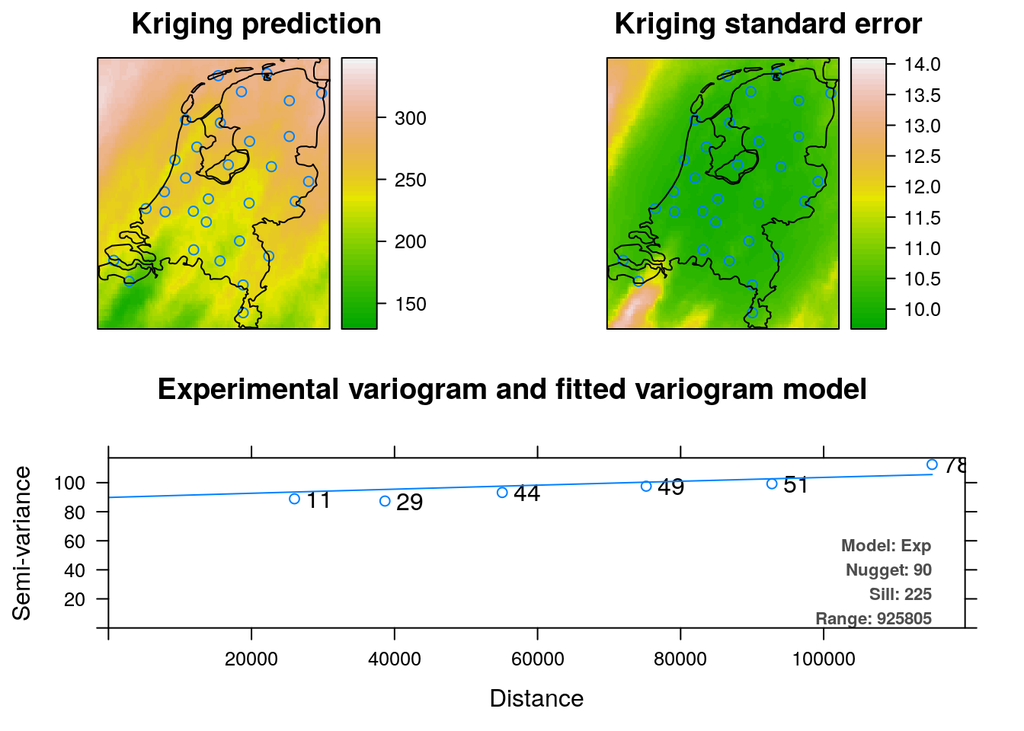

```r
# Krige Cross validation
ked_exp.cv <- autoKrige.cv(Q~var, var, model = c("Exp"),maxdist=mxdkrige,fix.values=c(NA,NA,NA), miscFitOptions = list(merge.small.bins = FALSE),verbose=c(FALSE,FALSE))
teller <- sum(ked_exp.cv$krige.cv_output$residual^2)
noemer <- sum((var$var-mean(var$var))^2)
ked_exp.r2 <- 1 - teller/noemer
ked.zscoremean <- mean(ked_exp.cv$krige.cv_output$zscore)
ked.zscore.var <- var(ked_exp.cv$krige.cv_output$zscore)
ked_exp.rmse<-rmse(ked_exp.cv$krige.cv_output$var1.pred,ked_exp.cv$krige.cv_output$observed)
plot(ked_exp,col=kleur.cols,breaks=kleur.breaks,sp.layout=list(pts=list("sp.points",obs.subset,pch=21),mymap.pro,mymap.pro_lakes))
```

```r
print(paste("R2=",round(ked_exp.r2,2),"RMSE=",round(ked_exp.rmse,2)))
```

```
## [1] "R2= 0.78 RMSE= 10.19"
```

```r
print(head(ked_exp$krige_output))
```

```
##   var1.pred var1.var var1.stdev
## 1  319.0599 159.5341   12.63068
## 2  321.8947 162.1759   12.73483
## 3  322.2087 161.9061   12.72423
## 4  321.8408 160.8295   12.68186
## 5  322.1059 160.4974   12.66876
## 6  322.1377 159.8897   12.64475
```

# Caret: Machine Learning Algorithms

For grid predictions with the caret package a combination of the caret::train and raster::predict functions is used. The input for the raster::predict function is either a raster Stack or raster Brick.

- Methods [here](http://topepo.github.io/caret/train-models-by-tag.html#Two_Class_Only.html).
- Some methods of the caret package run in parallel, background information can be found [here](https://cran.r-project.org/web/packages/doParallel/vignettes/gettingstartedParallel.pdf).
- Bug in Caret “Error in e$fun(obj, substitute(ex), parent.frame(), e$data) : worker initialization failed: there is no package called ‘caret’” can be fixed like [this](http://stackoverflow.com/questions/21029019/parallel-execution-of-train-in-caret-fails-with-function-not-found)

### Support Vector Machines

Sigma is depending on the predictor. The function “sigest” provides the value for sigma.

### Treebag

The treebag model also has no tuneGrid.

### Cubist

Cubist is a rule-based model but differs from other tree models. The final model combines models using a linear combination of two models. The different models are weighted based on their RMSE. The final model makes up the initial set of rules. The model tunes itself using committees and neighbors.

## Data preperation

```r
#cl<-makeCluster(6)
#registerDoParallel(cl)

obs.subset.Q<-subset(obs.subset,select="Q")
grid<-as(r.NED,"SpatialPixelsDataFrame")

ov<-over(obs.subset.Q,grid)
ov<-cbind(data.frame(obs.subset.Q["Q"]),ov)
ov<-rename(ov,c("DS_LON"="x"))
ov<-rename(ov,c("DS_LAT"="y"))
```

## Train control settings and tuning parameters

- The github post on [model training and tuning](http://topepo.github.io/caret/model-training-and-tuning.html).
- A list with all the available regression models can be found [online](http://topepo.github.io/caret/available-models.html), search for regression.

```r
control<-trainControl(method="cv",number=10,repeats=3) #setting a 10 fold-cross validation (best performing)
length<-10 #for the tuneLength of the models

#uncertainty measurements (calibration): 10W/m2, uncertainty sat: 30-50W/m2.
sigmaRangeReduced<-sigest(as.matrix(ov$layer))[1]
svmRadialRGridReduced<-expand.grid(.sigma=sigmaRangeReduced,.C=2^(seq(-4,4)))
svmLinearRGridReduced<-expand.grid(C=2^(seq(-4,4)))
ctreeGridReduced<-expand.grid(mincriterion=seq(from=0.1,to=0.5,by=0.1))
knnGridReduced<-expand.grid(.k=3:15)
gbmGridReduced<-expand.grid(.shrinkage=c(0.1),.n.trees=1:5,.interaction.depth=1:6,.n.minobsinnode=1:5)
earthGridReduced <- data.frame(.degree = 1, .nprune = (2:4)*2)
```

```r
#Linear Models
set.seed(50)
m1.lm<-caret::train(Q~layer,data=ov,method="lm",preProcess=c("center","scale","BoxCox"),tuneLength=length,trControl=control)

set.seed(50)
m2.glm<-caret::train(Q~layer,data=ov,method="glm",preProcess=c("center","scale","BoxCox"),tuneLength=length,trControl=control)

set.seed(50)
m3.gaussprLinear<-caret::train(Q~layer,data=ov,method="gaussprLinear",preProcess=c("center","scale","BoxCox"),verbose=FALSE,tuneLength=length,trControl=control)

#Support Vector Models
set.seed(50)
m4.svmRadial<-caret::train(Q~layer,data=ov,method="svmRadial",preProcess=c("center","scale","BoxCox"),verbose=FALSE,tuneLength=length,trControl=control,tuneGrid=svmRadialRGridReduced)

set.seed(50)
m5.svmLinear<-caret::train(Q~layer,data=ov,method="svmLinear",preProcess=c("center","scale","BoxCox"),verbose=FALSE,tuneLength=length,trControl=control,tuneGrid=svmLinearRGridReduced)

#Tree models
set.seed(50)
m6.treebag<-caret::train(Q~layer,data=ov,method="treebag",preProcess=c("center","scale","BoxCox"),verbose=FALSE,tuneLength=length,trControl=control)

set.seed(50)
m7.cubist<-caret::train(Q~layer,data=ov,method="cubist",preProcess=c("center","scale","BoxCox"),verbose=FALSE,tuneLength=length,trControl=control)

set.seed(50)
m8.ctree<-caret::train(Q~layer,data=ov,method="ctree",preProcess=c("center","scale","BoxCox"),tuneLength=length,trControl=control,tuneGrid=ctreeGridReduced)

#K-nearest neighbors
set.seed(50)
m9.knn<-caret::train(Q~layer,data=ov,method="knn",preProcess=c("center","scale","BoxCox"),verbose=FALSE,tuneLength=length,trControl=control,tuneGrid=knnGridReduced)

# Others
set.seed(50)
m10.earth<-caret::train(Q~layer,data=ov,method="earth",preProcess=c("center","scale","BoxCox"),tuneLength=length,trControl=control,tuneGrid=earthGridReduced)

set.seed(50)
m11.gbm<-caret::train(Q~layer,data=ov,method="gbm",preProcess=c("center","scale","BoxCox"),tuneLength=length,trControl=control,tuneGrid=gbmGridReduced,verbose=FALSE)
```

```r
results<-resamples(list(lm=m1.lm,
                        glm=m2.glm,
                        gaussprLinear=m3.gaussprLinear,
                        svmRadial=m4.svmRadial,
                        svmLinear=m5.svmLinear,
                        treebag=m6.treebag,
                        cubist=m7.cubist,
                        ctreer=m8.ctree,
                        knn=m9.knn,
                        earth=m10.earth,
                        gbm=m11.gbm))
summary(results)
```

```
##
## Call:
## summary.resamples(object = results)
##
## Models: lm, glm, gaussprLinear, svmRadial, svmLinear, treebag, cubist, ctreer, knn, earth, gbm
## Number of resamples: 10
##
## RMSE
##                 Min. 1st Qu. Median  Mean 3rd Qu.  Max. NA's
## lm             5.765   8.159 12.220 12.64   14.08 29.47    0
## glm            5.765   8.159 12.220 12.64   14.08 29.47    0
## gaussprLinear  5.981   8.533 12.170 12.49   14.06 27.23    0
## svmRadial      4.967   8.268 13.180 14.31   14.69 37.67    0
## svmLinear      6.996   9.051 10.830 11.92   14.98 17.96    0
## treebag        6.897  10.400 11.330 16.18   23.91 30.83    0
## cubist         6.419   8.149 11.910 12.60   14.38 27.95    0
## ctreer        10.040  14.030 20.720 19.68   23.62 29.21    0
## knn            6.408   9.611 13.040 13.33   15.46 22.63    0
## earth          5.912   8.082  9.964 11.84   14.68 23.49    0
## gbm            5.238  11.030 17.130 18.89   26.08 35.19    0
##
## Rsquared
##                 Min. 1st Qu. Median   Mean 3rd Qu. Max. NA's
## lm            0.6971  0.9373 0.9893 0.9291       1    1    0
## glm           0.6971  0.9373 0.9893 0.9291       1    1    0
## gaussprLinear 0.6971  0.9373 0.9893 0.9291       1    1    0
## svmRadial     0.1540  0.7526 0.9790 0.8396       1    1    0
## svmLinear     0.6971  0.9373 0.9893 0.9291       1    1    0
## treebag       0.5129  0.5341 0.8042 0.7735       1    1    0
## cubist        0.6971  0.9373 0.9899 0.9292       1    1    0
## ctreer        0.5179  0.6404 0.9145 0.8145       1    1    5
## knn           0.5647  0.7462 0.9497 0.8572       1    1    0
## earth         0.6737  0.7588 0.9866 0.8979       1    1    0
## gbm           0.6490  0.7798 0.9719 0.8846       1    1    0
```

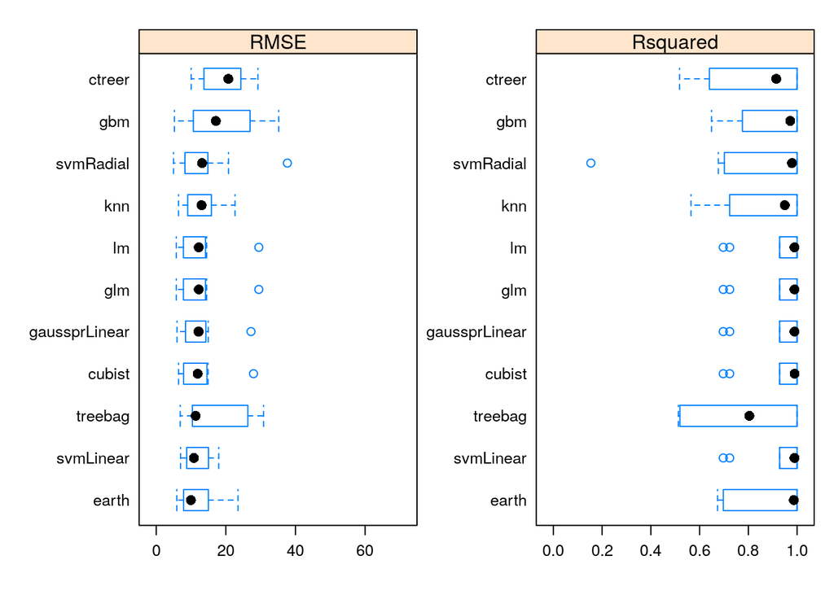

```r
bwplot(results,scales=list(relation="free"),xlim=list(c(0,70),c(0,1)))
```

```r
modelDifferences<-diff(results)
print(modelDifferences) #see str(modelDifferences) for values. Large p-values: the models fail to show any diference in performance (Kuhn&Johnson 2013, p.101 )
```

```
##
## Call:
## diff.resamples(x = results)
##
## Models: lm, glm, gaussprLinear, svmRadial, svmLinear, treebag, cubist, ctreer, knn, earth, gbm
## Metrics: RMSE, Rsquared
## Number of differences: 55
## p-value adjustment: bonferroni
```

## Model selection

Comparing the models showed the following results:

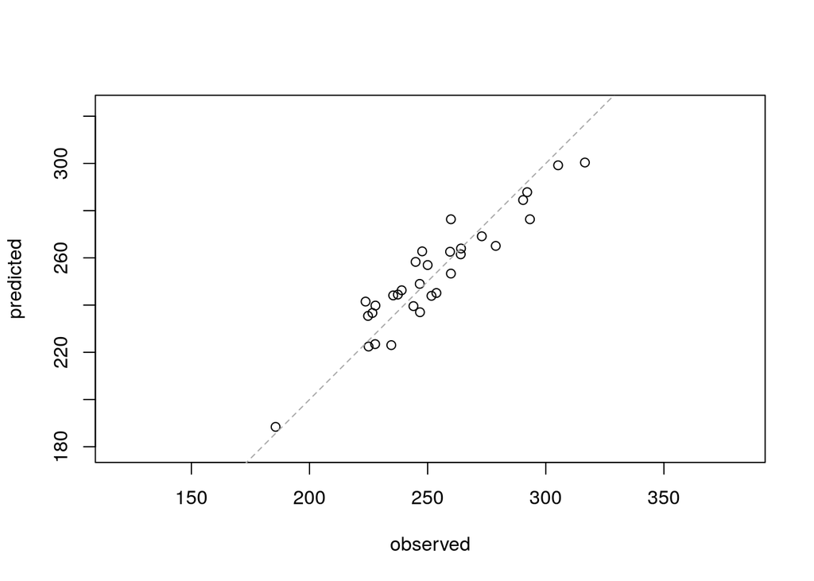

```r
final.model<-m5.svmLinear

st<-stack(grid)
p1.caret<-raster::predict(model=final.model,object=st)

p1.ASC<-asc.from.raster(p1.caret)
p1.spdf<-asc2spixdf(p1.ASC)
proj4string(p1.spdf)<-pro

p1.var<-over(var.Q,p1.spdf)

n<-names(p1.var)
p1.diff<-p1.var[n]-var.Q$Q

observed<-data.frame(var.Q$Q)
predicted<-p1.var[n]

axisRange<-extendrange(c(observed,predicted))
obs.vs.pred<-data.frame(observed,predicted)
pred.vs.res<-data.frame(predicted,p1.diff)

plot(obs.vs.pred,xlab="observed",ylab="predicted",ylim=axisRange,xlim=axisRange,asp=1)
abline(0, 1, col = "darkgrey", lty = 2)
```

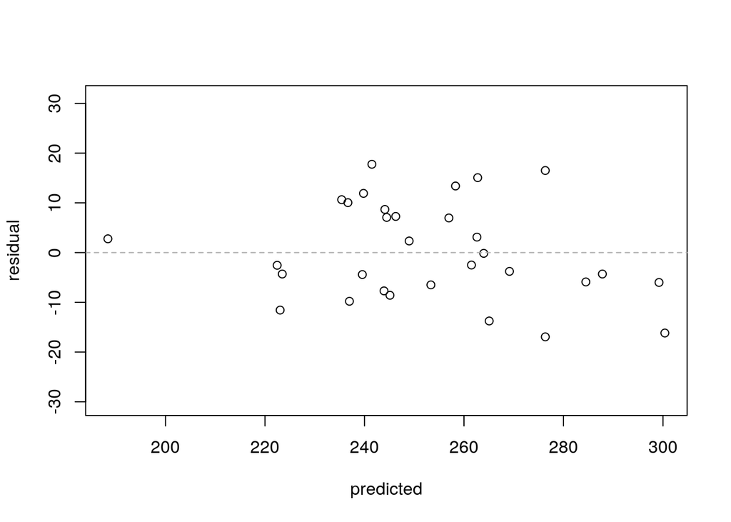

```r
plot(pred.vs.res,xlab="predicted",ylab="residual",asp=1)
abline(h = 0, col = "darkgrey", lty = 2)
```

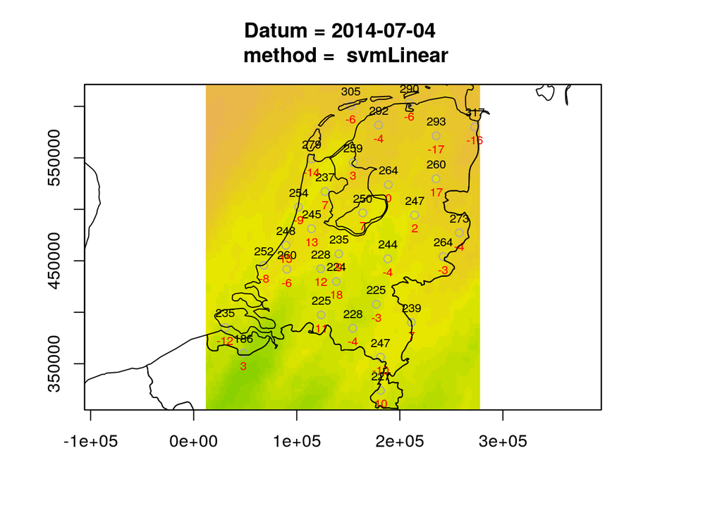

```r
plot(p1.caret,col=kleur.cols,breaks=kleur.breaks,main=paste("Datum =",time,"\n","method = ",final.model$method),legend=F)
plot(obs.subset,bg=(kleur.cols[kleur.data]),
     col="darkgrey",pch=21,add=TRUE)
text(obs.subset$DS_LON,obs.subset$DS_LAT,round(obs.subset$Q,0),pos=3,cex=0.7)
text(obs.subset$DS_LON,obs.subset$DS_LAT,round(p1.diff[[n]],0),pos=1,cex=0.7,col="red")
plot(mymap.pro,add=TRUE)
plot(mymap.pro_lakes,add=TRUE)
```

```r
obs.vs.pred<-data.frame(observed,predicted)
pred.vs.res<-data.frame(predicted,p1.diff)
axisRange <- extendrange(c(observed, predicted))
```

## Comparing models

```r
st$lm<-raster::predict(model=m1.lm,object=st)
st$glm<-raster::predict(model=m2.glm,object=st)
st$gaussprLinear<-raster::predict(model=m3.gaussprLinear,object=st)
st$svmRadial<-raster::predict(model=m4.svmRadial,object=st)
st$svmLinear<-raster::predict(model=m5.svmLinear,object=st)
st$treebag<-raster::predict(model=m6.treebag,object=st)
st$cubist<-raster::predict(model=m7.cubist,object=st)
st$ctree<-raster::predict(model=m8.ctree,object=st)
st$knn<-raster::predict(model=m9.knn,object=st)
st$earth<-raster::predict(model=m10.earth,object=st)
st$gbm<-raster::predict(model=m11.gbm,object=st)
st$kriging<-ked_exp$krige_output$var1.pred
print(st)
```

```
## class       : RasterStack
## dimensions  : 124, 106, 13144, 13  (nrow, ncol, ncell, nlayers)
## resolution  : 2510, 2550  (x, y)
## extent      : 11776.11, 277836.1, 305127.7, 621327.7  (xmin, xmax, ymin, ymax)
## coord. ref. : +init=epsg:28992 +proj=sterea +lat_0=52.15616055555555 +lon_0=5.38763888888889 +k=0.9999079 +x_0=155000 +y_0=463000 +ellps=bessel +towgs84=565.4171,50.3319,465.5524,-0.398957388243134,0.343987817378283,-1.87740163998045,4.0725 +units=m +no_defs
## names       :    layer,       lm,      glm, gaussprLinear, svmRadial, svmLinear,  treebag,   cubist,    ctree,      knn,    earth,      gbm,  kriging
## min values  : 153.2380, 156.0101, 156.0101,      159.1250,  230.5037,  162.9439, 230.6457, 157.3497, 226.6782, 218.2581, 170.1280, 236.7220, 142.7808
## max values  : 324.8681, 346.3151, 346.3151,      343.2911,  294.5542,  341.4739, 279.7684, 347.7953, 288.6429, 301.0706, 359.0641, 269.6611, 334.5249
```

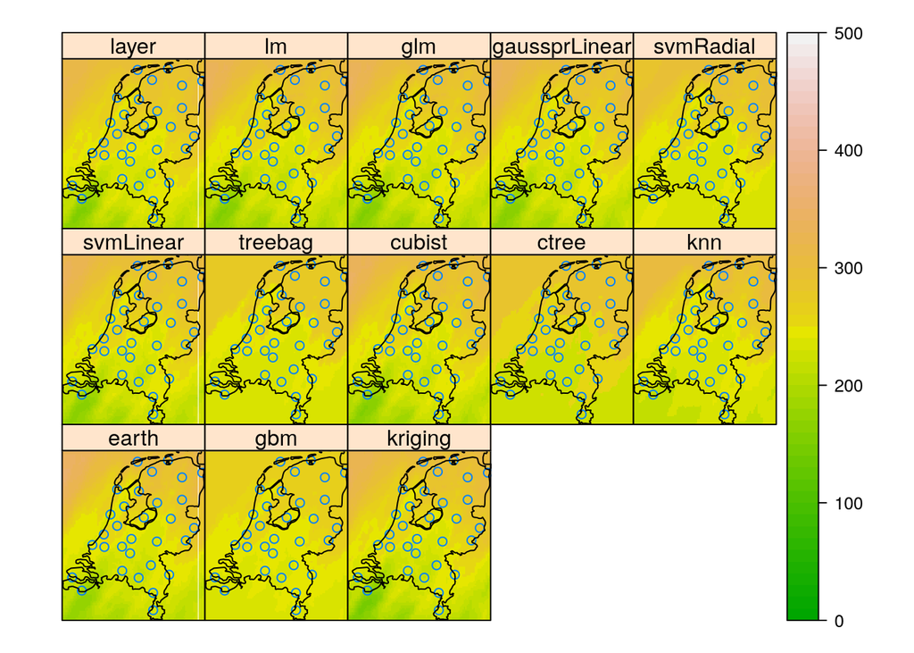

```r
spplot(st,col.regions=kleur.cols,at=kleur.breaks,
       sp.layout=list(pts=list("sp.points",obs.subset,pch=21),mymap.pro,mymap.pro_lakes))
```